# Bài tập 4: Phân tích Khí quyển Sao Hỏa

Dự đoán xu hướng nhiệt độ bằng Local Polynomial Regression

Quang Nguyen

2026-01-31

# 1 Giới thiệu

Dữ liệu `mars.dat` cung cấp hồ sơ nhiệt độ-áp suất của khí quyển sao Hỏa, được tàu vũ trụ **Mars Global Surveyor** đo vào năm 2003 bằng kỹ thuật che khuất sóng vô tuyến.

**Mục tiêu:**

- 1. Dự đoán xu hướng thay đổi của nhiệt độ theo bán kính tâm hành tinh
- 2. Phân tích xu hướng theo từng quỹ đạo (orbit) khác nhau
- 3. Phân tích xu hướng nhiệt độ theo áp suất thay thế cho bán kính

# 2 Load hàm từ Bài tập 3

```r
# Load hàm Local Polynomial Regression từ Exercise 3
source("../Problem 3/exercise_03.R")
```

**Các hàm chính:**

- `gaussian_kernel(u)`: Hàm kernel Gaussian
- `calculate_cv_score(h, x, y, p)`: Tính Cross-Validation score
- `locpoly_reg(x, y, p, h, eval_x)`: Hồi quy đa thức địa phương

# 3 Load và Khám phá Dữ liệu

## 3.1 Dữ liệu mars.dat (đơn giản)

```r
# Load mars.dat
mars <- read.table("mars.dat", header = TRUE)

cat("Cấu trúc dữ liệu mars.dat:\n")
```

```
## Cấu trúc dữ liệu mars.dat:
```

```r
str(mars)
```

```
## 'data.frame':    80 obs. of  3 variables:
##  $ radius          : num  3380 3403 3389 3391 3384 ...
##  $ temperature     : num  179 145 165 157 170 ...
##  $ sigmatemperature: num  0.466 3.85 0.873 1.56 0.857 3.16 1.66 2.9 0.628 1.38 ...
```

```r
cat("\nThống kê mô tả:\n")
```

```
##
## Thống kê mô tả:
```

```r
summary(mars)
```

```
##      radius      temperature    sigmatemperature
##  Min.   :3376   Min.   :144.2   Min.   : 0.2720
##  1st Qu.:3384   1st Qu.:149.8   1st Qu.: 0.5883
##  Median :3391   Median :156.6   Median : 1.2600
##  Mean   :3392   Mean   :160.0   Mean   : 2.4070
##  3rd Qu.:3401   3rd Qu.:171.4   3rd Qu.: 2.9650
##  Max.   :3411   Max.   :181.9   Max.   :10.0000
```

**Giải thích các biến:**

- `radius`: Bán kính tâm hành tinh (km) - tương ứng với độ cao
- `temperature`: Nhiệt độ khí quyển (K - Kelvin)
- `sigmatemperature`: Sai số đo lường nhiệt độ

## 3.2 Dữ liệu marsbig.dat (đầy đủ)

```r
# Load marsbig.dat
marsbig <- read.table("marsbig.dat", header = TRUE)

cat("Cấu trúc dữ liệu marsbig.dat:\n")
```

```
## Cấu trúc dữ liệu marsbig.dat:
```

```r
str(marsbig)
```

```
## 'data.frame':    324 obs. of  11 variables:
##  $ radius          : num  3376 3377 3378 3378 3379 ...
##  $ latitude        : num  71.5 71.5 71.5 71.5 71.5 ...
##  $ longitude       : num  265 265 265 265 265 ...
##  $ geopotential    : int  -14087 -11125 -8369 -5520 -2692 152 2998 5824 8664 11500 ...
##  $ pressure        : num  751 687 631 578 530 ...
##  $ sigmapressure   : num  2.38 2.34 2.31 2.27 2.23 2.19 2.15 2.11 2.08 2.04 ...
##  $ temperature     : num  173 171 171 171 171 ...
##  $ sigmatemperature: num  0.449 0.475 0.509 0.543 0.58 0.62 0.663 0.71 0.758 0.808 ...
##  $ mnd             : num  3.14e+23 2.92e+23 2.67e+23 2.45e+23 2.25e+23 ...
##  $ sigmamnd        : num  2.12e+20 2.11e+20 2.12e+20 2.12e+20 2.12e+20 ...
##  $ orbit           : int  1 1 1 1 1 1 1 1 1 1 ...
```

**Giải thích các biến trong marsbig.dat:**

| Biến | Mô tả |
| --- | --- |
| `radius` | Bán kính tâm hành tinh (km) |
| `latitude` | Vĩ độ (độ) |
| `longitude` | Kinh độ (độ) |
| `geopotential` | Địa thế năng |
| `pressure` | Áp suất khí quyển (Pa) |
| `sigmapressure` | Sai số áp suất |
| `temperature` | Nhiệt độ (K) |
| `sigmatemperature` | Sai số nhiệt độ |
| `mnd` | Molecular number density |
| `sigmamnd` | Sai số mnd |
| `orbit` | Số thứ tự quỹ đạo |

```r
cat("\nPhân bố quan sát theo quỹ đạo:\n")
```

```
##
## Phân bố quan sát theo quỹ đạo:
```

```r
print(table(marsbig$orbit))
```

```
##
##  1  2  3  4  5  6  7
## 46 46 47 47 46 46 46
```

```r
cat(sprintf("\nTổng số quan sát: %d\n", nrow(marsbig)))
```

```
##
## Tổng số quan sát: 324
```

## 3.3 Trực quan hóa dữ liệu ban đầu

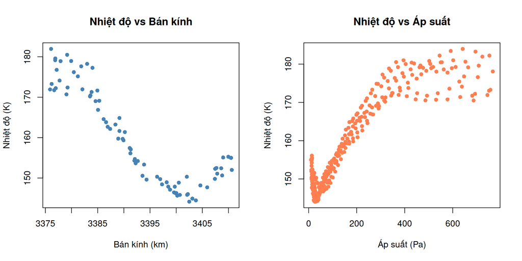

```r
par(mfrow = c(1, 2))

# Temperature vs Radius
plot(mars$radius, mars$temperature,
     pch = 16, col = "steelblue",
     xlab = "Bán kính (km)",
     ylab = "Nhiệt độ (K)",
     main = "Nhiệt độ vs Bán kính")

# Temperature vs Pressure (marsbig)
plot(marsbig$pressure, marsbig$temperature,
     pch = 16, col = "coral",
     xlab = "Áp suất (Pa)",
     ylab = "Nhiệt độ (K)",
     main = "Nhiệt độ vs Áp suất")
```

```r
par(mfrow = c(1, 1))
```

# 4 Phần (a): Nhiệt độ theo Bán kính

## 4.1 Áp dụng Local Polynomial Regression

Sử dụng hàm `locpoly_reg()` từ bài tập 3 với các bậc đa thức khác nhau:

- **p = 0**: Nadaraya-Watson (local constant)
- **p = 1**: Local linear regression
- **p = 2**: Local quadratic regression

```r
x <- mars$radius
y <- mars$temperature

cat("=== Local Constant (p=0) - Nadaraya-Watson ===\n")
```

```
## === Local Constant (p=0) - Nadaraya-Watson ===
```

```r
fit_p0 <- locpoly_reg(x, y, p = 0)
```

```
## Bandwidth h is NULL. Performing Cross-Validation...
## Selected optimal bandwidth h = 1.4031 (CV Score = 6.7352)
```

```r
cat("\n=== Local Linear (p=1) ===\n")
```

```
##
## === Local Linear (p=1) ===
```

```r
fit_p1 <- locpoly_reg(x, y, p = 1)
```

```
## Bandwidth h is NULL. Performing Cross-Validation...
## Selected optimal bandwidth h = 1.8204 (CV Score = 6.6688)
```

```r
cat("\n=== Local Quadratic (p=2) ===\n")
```

```
##
## === Local Quadratic (p=2) ===
```

```r
fit_p2 <- locpoly_reg(x, y, p = 2)
```

```
## Bandwidth h is NULL. Performing Cross-Validation...
## Selected optimal bandwidth h = 4.6304 (CV Score = 6.6214)
```

## 4.2 So sánh Bandwidth tối ưu

```r
bandwidth_comparison <- data.frame(
  Degree = c("p=0 (Constant)", "p=1 (Linear)", "p=2 (Quadratic)"),
  Bandwidth = c(fit_p0$h, fit_p1$h, fit_p2$h)
)
knitr::kable(bandwidth_comparison,
             caption = "Bandwidth tối ưu theo bậc đa thức",
             digits = 4)
```

Bandwidth tối ưu theo bậc đa thức

| Degree | Bandwidth |
| --- | --- |
| p=0 (Constant) | 1.4031 |
| p=1 (Linear) | 1.8204 |
| p=2 (Quadratic) | 4.6304 |

## 4.3 Tạo đường cong làm mượt

```r
# Tạo lưới điểm để đánh giá
eval_x <- seq(min(x), max(x), length.out = 200)

# Fit trên lưới điểm
fit_smooth_p0 <- locpoly_reg(x, y, p = 0, h = fit_p0$h, eval_x = eval_x)
fit_smooth_p1 <- locpoly_reg(x, y, p = 1, h = fit_p1$h, eval_x = eval_x)
fit_smooth_p2 <- locpoly_reg(x, y, p = 2, h = fit_p2$h, eval_x = eval_x)
```

## 4.4 Trực quan hóa kết quả

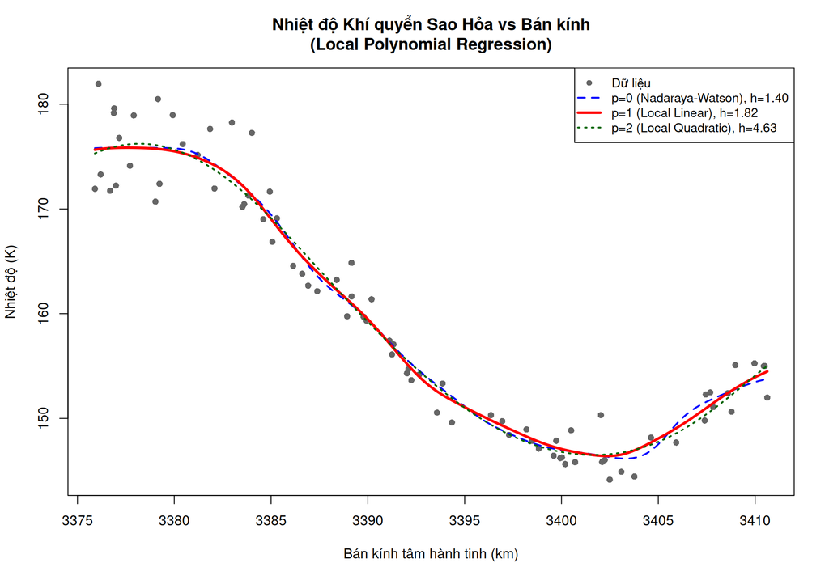

```r
plot(x, y, pch = 16, col = "gray40", cex = 1,
     xlab = "Bán kính tâm hành tinh (km)",
     ylab = "Nhiệt độ (K)",
     main = "Nhiệt độ Khí quyển Sao Hỏa vs Bán kính\n(Local Polynomial Regression)")

# Thêm các đường fit
lines(fit_smooth_p0$x, fit_smooth_p0$fitted, col = "blue", lwd = 2, lty = 2)
lines(fit_smooth_p1$x, fit_smooth_p1$fitted, col = "red", lwd = 3)
lines(fit_smooth_p2$x, fit_smooth_p2$fitted, col = "darkgreen", lwd = 2, lty = 3)

legend("topright",
       legend = c("Dữ liệu",
                  sprintf("p=0 (Nadaraya-Watson), h=%.2f", fit_p0$h),
                  sprintf("p=1 (Local Linear), h=%.2f", fit_p1$h),
                  sprintf("p=2 (Local Quadratic), h=%.2f", fit_p2$h)),
       col = c("gray40", "blue", "red", "darkgreen"),
       pch = c(16, NA, NA, NA),
       lty = c(NA, 2, 1, 3),
       lwd = c(NA, 2, 3, 2),
       cex = 0.9)
```